# Predict Buy Now Pay Later service adoption and delinquency using SHED data

## Dimensionality Reduction - PCA

### KMO Analysis

The Kaiser-Meyer-Olkin (KMO) Test is a statistical measure used to determine the sampling adequacy of data before conducting a Principal Component Analysis (PCA). It assesses the proportion of variance among the variables that might be common variance. A KMO above 0.6 is typically considered acceptable. A high KMO score confirms that the variables share enough common core information to make PCA a meaningful and effective reduction technique; conversely, a low score warns you that the data is too “noisy” or independent to be clustered into common components.

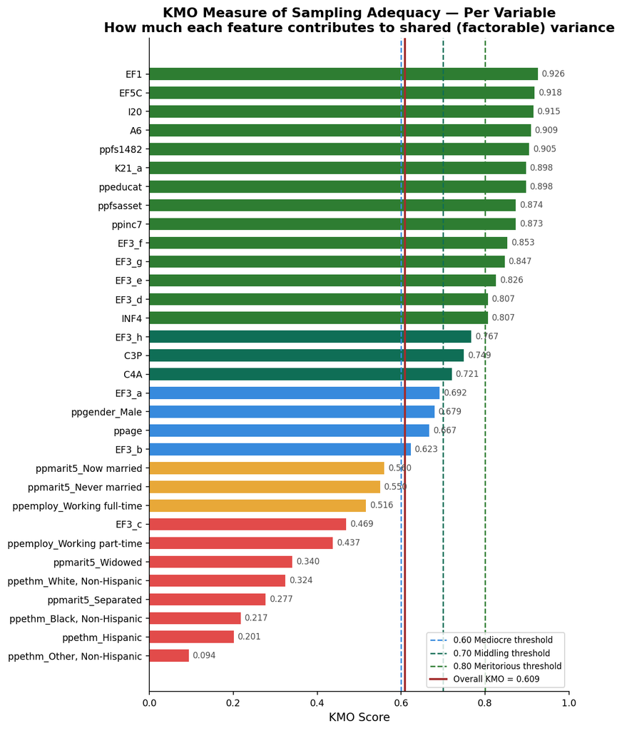

The KMO analysis shows the overall KMO = 0.609 with only 10 variables over 0.85 KMO.

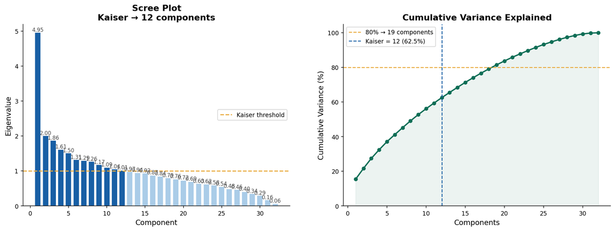

The cumulative variance graph shows that only 12 components have Eigenvalue > 1.0, meaning the principal component explains more variance than a single original variable. However, the cumulative explained variance of 12 components is only 62.5%. In order to explain the variance for 80%, 19 components are needed which is more than half of the total predictive variables. This is a sign that PCA does not meaningfully reduce the dimensionality, likely due to the independence of each survey questions with not much overlapping information. We are going to skip the PCA and instead introduce L1/L2 penalty to reduce the model complexity in order to avoid overfit.